# jekyll-jupyter-notebook20240829-2492-ttsj4l

### We can also look at **modern L2C signals** (`-fr=20`).

These are not available for all satellites (satellites broadcasting this signal changes with time, mostly additive) but offer improved, higher gain SNR.

```
minimum elevation angle (degrees) for this dataset:  0.0184
Average reflector height value: 5.2
```

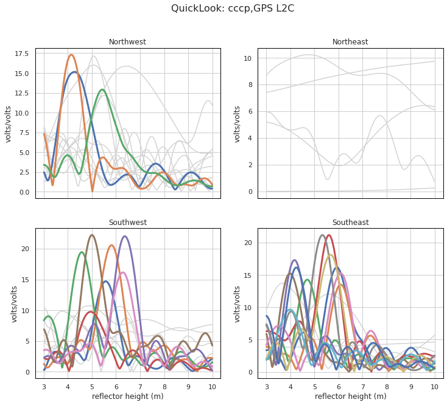

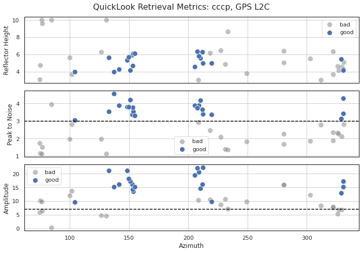

```python
values, metrics = quicklook(station, year, doy=doy,
                                         e1=5, e2=13, h1=3, h2=10, fr=20, pltscreen=False)

pretty_plots(station, values, 'GPS L2C', metrics)
```

### Don't forget we have **GLONASS signals** too! (`-fr=101`)

```
minimum elevation angle (degrees) for this dataset:  0.0184
Average reflector height value: 5.3
```

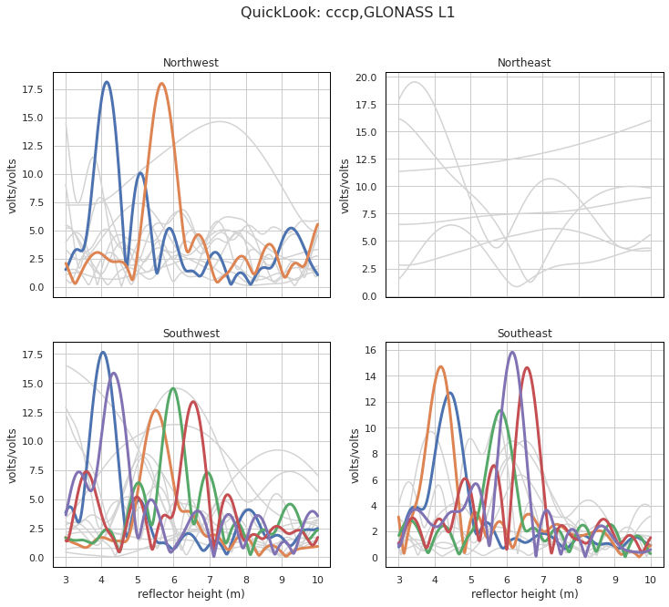

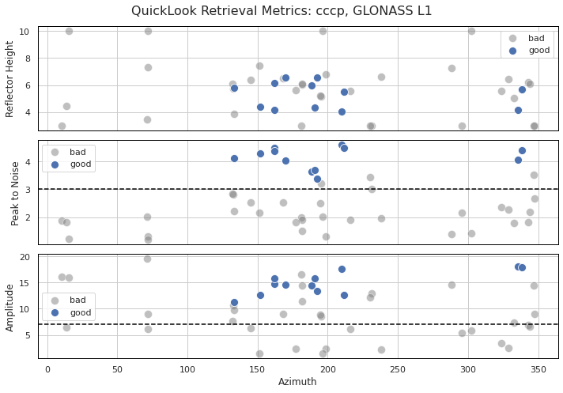

```python
values, metrics = quicklook(station, year, doy=doy,
                                         e1=5, e2=13, h1=3, h2=10, fr=101, pltscreen=False)

pretty_plots(station, values, 'GLONASS L1', metrics)
```

**Now we also get retrievals in southern azimuths (150-200 deg).**

Multi constellation tracking has many application benefits-- For our application it adds retrievals in addition to satellite geometry diversity.

## Analyze the Data

Next we will set up our analysis for the three days of data we've been provided.

Our workflow is as follows:

1. `rinex2snr()` Translates the files to snr files
2. `make_json_input()` Builds a configuration file for reflectometery processing parameters
3. `gnssir()` Estimates reflection heights (RH) that meet QC metrics
4. `subdaily()` Concatenates RH timeseries, removes outliers, computes [RH dot correction](https://www.kristinelarson.net/wp-content/uploads/2015/10/LarsonIEEE_2013.pdf) and plots timeseries

```python
#define our processing days of interest:

doy_start=84
doy_end=86

# Move over rinex to CWD
for d in np.arange(doy,doy_end+1):
    file = "cccp%03d0.22o" %d
    filedir='images/'+file
    if not os.path.exists(file):
        shutil.copy(filedir, os.getcwd())

rinex2snr(station, year, doy_start, doy_end=doy_end, orb='gnss')
```

```
SNR file exists /shared/analyst/gnssrefl_jupyter/2022/snr/cccp/cccp0840.22.snr66
SNR file exists /shared/analyst/gnssrefl_jupyter/2022/snr/cccp/cccp0850.22.snr66
SNR file exists /shared/analyst/gnssrefl_jupyter/2022/snr/cccp/cccp0860.22.snr66
Feedback written to subdirectory logs
```

### `make_json_input()`

The next step is to create the json file that gnssir reads with the values that we have decided on from the quicklook step. In this case we will set the elevation angles and the heights. We will also set the parameter allfreq to true (and modify this shortly).

```python
lat = 1.820
long = -78.729
height = 21.333

make_json(station, lat, long, height, e1=5, e2=13, h1=3, h2=10, allfreq=True)
```

```
writing out to: /shared/analyst/gnssrefl_jupyter/input/cccp.json
```

```python
# This is the json file that was created with the defaults/parameters you set above
json_file = f'{refl_code_loc}/input/{station}.json'
with open(json_file, "r") as myfile:
    file = json.load(myfile)

file
```

```
{'station': 'cccp',
 'lat': 1.82,
 'lon': -78.729,
 'ht': 21.333,
 'minH': 3,
 'maxH': 10,
 'e1': 5,
 'e2': 13,
 'NReg': [3, 10],
 'PkNoise': 2.7,
 'polyV': 4,
 'pele': [5, 30],
 'ediff': 2,
 'desiredP': 0.005,
 'azval': [0, 90, 90, 180, 180, 270, 270, 360],
 'freqs': [1, 20, 5, 101, 102, 201, 205, 206, 207, 208, 302, 306],
 'reqAmp': [6.0, 6.0, 6.0, 6.0, 6.0, 6.0, 6.0, 6.0, 6.0, 6.0, 6.0, 6.0],
 'refraction': True,
 'overwriteResults': True,
 'seekRinex': False,
 'wantCompression': False,
 'plt_screen': False,
 'onesat': None,
 'screenstats': False,
 'pltname': 'cccp_lsp.png',
 'delTmax': 75}
```

We need to select azimuth ranges that include useful reflections.

We can edit the json file manually using a text editor, or use the cell below to help edit the json file.

**We cannot set azimuth ranges > 100 degrees.** This limit is built into gnssrefl to ensure rising and setting arcs reflector heights are estimated independently.

We are also going to edit out the Galileo and Beidou signals since they are not included in these rinex files.

[figure not shown]

```python
# Now lets edit the json file
with open(json_file, "r") as myfile:
    file = json.load(myfile)

# Here is where we can 'hand edit' values in the json file
# lets edit the azimuths. We set these values by looking at the metrics qc plot above
file['azval'] = [70,150,150,230]
file['freqs'] = [1,20,5,101,102]
os.remove(json_file)

with open(json_file, 'w') as f:
    json.dump(file, f, indent=4)

# now lets view it again and note the difference
with open(json_file, "r") as myfile:
    file = json.load(myfile)

file
```

```
{'station': 'cccp',
 'lat': 1.82,
 'lon': -78.729,
 'ht': 21.333,
 'minH': 3,
 'maxH': 10,
 'e1': 5,
 'e2': 13,
 'NReg': [3, 10],
 'PkNoise': 2.7,
 'polyV': 4,
 'pele': [5, 30],
 'ediff': 2,
 'desiredP': 0.005,
 'azval': [70, 150, 150, 230],
 'freqs': [1, 20, 5, 101, 102],
 'reqAmp': [6.0, 6.0, 6.0, 6.0, 6.0, 6.0, 6.0, 6.0, 6.0, 6.0, 6.0, 6.0],
 'refraction': True,
 'overwriteResults': True,
 'seekRinex': False,
 'wantCompression': False,
 'plt_screen': False,
 'onesat': None,
 'screenstats': False,
 'pltname': 'cccp_lsp.png',
 'delTmax': 75}
```

### `gnssir()`

Now we will run gnssir, the utility that estimates reflector heights and applies the quality control metrics defined in the json config.

```python
year = 2022
doy_start = 84
doy_end = 86
gnssir(station, year, doy_start, doy_end=doy_end, screenstats=False)
```

```
refraction file exists
Results will be written to: /shared/analyst/gnssrefl_jupyter/2022/results/cccp//084.txt
Results will be written to: /shared/analyst/gnssrefl_jupyter/2022/results/cccp//085.txt
Results will be written to: /shared/analyst/gnssrefl_jupyter/2022/results/cccp//086.txt
```

### `subdaily()`

This the function that concatenates the qc'ed reflection heights output from gnssir() and makes an effort to apply an RH Dot correction to account for change in reflector height over the individual processed arc.

```
0.0 300.0 new optional inputs
Will pick up and concatenate daily result files
Will remove daily outliers greater than  2.5  sigma
Plot to the screen has been set to  True
>>>>>>>>>>>>>>>>>>>>>>>> readin RH data <<<<<<<<<<<<<<<<<<<<<<<<<<<<<<
Read in the RH retrievals for  2022  and these days:  84 86
Number of initial RH retrievals 209
0  points removed for azimuth constraints  0 360
0  points removed for amplitude constraint
0  points removed for peak2noise constraints
RH retrievals after all commandline constraints 209
png file saved as:  /shared/analyst/gnssrefl_jupyter/Files/cccp_combined.png
png file saved as:  /shared/analyst/gnssrefl_jupyter/Files/cccp_outliers_hunting.png
```

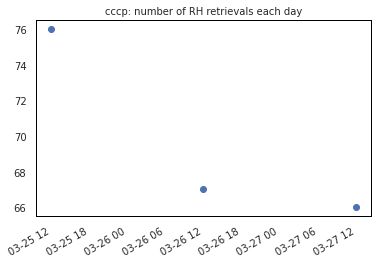

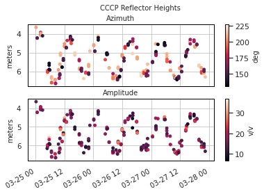

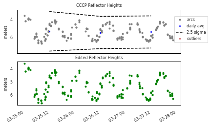

```
outliers written to file:  outliers.txt
no outlier points to write to a file
209  observations will be written to  /shared/analyst/gnssrefl_jupyter/Files/cccp_all.txt
Edited observations 209
209  observations will be written to  /shared/analyst/gnssrefl_jupyter/Files/cccp_subdaily_edits.txt
Percent of observations removed:  0.0
```

```python
subdaily(station=station, year=year, doy1=doy, doy2=doy_end, plt=True)
```

These are big tides- We can check our analysis by looking for co-located tidal data. There are several archives of tidal data; one is the [IOC sea level monitoring website.](https://www.ioc-sealevelmonitoring.org/)

We are lucky, it appears as though there is a tide gauge, [TUMC2](https://www.ioc-sealevelmonitoring.org/station.php?code=tumc2), on the same dock!

[figure not shown]

# [INVSNR](https://github.com/kristinemlarson/gnssrefl/blob/master/README_invsnr.md)

The library for retrieving reflector heights from inverse modeling [(Strandberg et al., 2016)](https://agupubs.onlinelibrary.wiley.com/doi/full/10.1002/2016RS006057) is not yet included in the notebook implementation, but is well documented in [a readme](https://github.com/kristinemlarson/gnssrefl/blob/master/README_invsnr.md) for running from the command line.

`invsnr_input cccp 3 10 5 13 -lat 1.82 -lon -78.729 -height 21.333 -a1 75 -a2 230`

`invsnr cccp 2022 84 L1+L2+L5 -doy_end 86`

[figure not shown]

```python
# RUN ONLY IF INTERESTED IN RESETING PROCESSING on SHARED DIRECTORY within QHUB
#os.remove(file)
import os
import glob

files = glob.glob('/shared/analyst/gnssrefl_jupyter/2022/snr/cccp/*snr*', recursive=True)

for f in files:
    os.remove(f)


files = glob.glob('/shared/analyst/gnssrefl_jupyter/2022/results/cccp/*')

for f in files:
    os.remove(f)


for d in np.arange(doy,doy_end+1):
    file = "cccp%03d0.22o" %d
    if os.path.exists(file):
        os.remove(file)
```